# Life Expectancy Prediction Assignment

This notebook covers the implementation of OLS and Logit regression models using the 'Life Expectancy' dataset.

```python
# Import necessary libraries
import pandas as pd
import numpy as np
import matplotlib.pyplot as plt
import seaborn as sns
import statsmodels.api as sm
from sklearn.metrics import mean_squared_error, r2_score, accuracy_score, confusion_matrix, roc_curve, auc
from sklearn.model_selection import train_test_split
```

## Load the Dataset

```python
# prompt: mount Google drive

from google.colab import drive
drive.mount('/content/drive')
```

```python
# Load the dataset
file_path = '/content/drive/MyDrive/FALL2-AA5000/Final Project/updated_life_expectancy_data.csv'  # Replace with your file path
df = pd.read_csv(file_path)

# Display first few rows
df.head()
```

|  | Year | Status | Life expectancy | Adult Mortality | infant deaths | Alcohol | percentage expenditure | Hepatitis B | Measles | BMI | ... | Total expenditure | Diphtheria | HIV/AIDS | GDP | Population | thinness 1-19 years | thinness 5-9 years | Income composition of resources | Schooling | Life_expectancy_category |
| --- | --- | --- | --- | --- | --- | --- | --- | --- | --- | --- | --- | --- | --- | --- | --- | --- | --- | --- | --- | --- | --- |
| 0 | 2015 | Developing | 65.0 | 263.0 | 62 | 0.01 | 71.279624 | 65.0 | 1154 | 19.1 | ... | 8.16 | 65.0 | 0.1 | 584.259210 | 33736494.0 | 17.2 | 17.3 | 0.479 | 10.1 | Low |
| 1 | 2014 | Developing | 59.9 | 271.0 | 64 | 0.01 | 73.523582 | 62.0 | 492 | 18.6 | ... | 8.18 | 62.0 | 0.1 | 612.696514 | 327582.0 | 17.5 | 17.5 | 0.476 | 10.0 | Low |
| 2 | 2013 | Developing | 59.9 | 268.0 | 66 | 0.01 | 73.219243 | 64.0 | 430 | 18.1 | ... | 8.13 | 64.0 | 0.1 | 631.744976 | 31731688.0 | 17.7 | 17.7 | 0.470 | 9.9 | Low |
| 3 | 2012 | Developing | 59.5 | 272.0 | 69 | 0.01 | 78.184215 | 67.0 | 2787 | 17.6 | ... | 8.52 | 67.0 | 0.1 | 669.959000 | 3696958.0 | 17.9 | 18.0 | 0.463 | 9.8 | Low |
| 4 | 2011 | Developing | 59.2 | 275.0 | 71 | 0.01 | 7.097109 | 68.0 | 3013 | 17.2 | ... | 7.87 | 68.0 | 0.1 | 63.537231 | 2978599.0 | 18.2 | 18.2 | 0.454 | 9.5 | Low |

5 rows × 22 columns

Reading the dataset

```python
df.shape
```

```
(2938, 22)
```

```python
df.columns
```

```
Index(['Year', 'Status', 'Life expectancy ', 'Adult Mortality',
       'infant deaths', 'Alcohol', 'percentage expenditure', 'Hepatitis B',
       'Measles ', ' BMI ', 'under-five deaths ', 'Polio', 'Total expenditure',
       'Diphtheria ', ' HIV/AIDS', 'GDP', 'Population',
       ' thinness  1-19 years', ' thinness 5-9 years',
       'Income composition of resources', 'Schooling',
       'Life_expectancy_category'],
      dtype='object')
```

## Data Preprocessing

After reviewing the data, it appears there are no unique values. I will revisit it once more for confirmation.

```python
df.nunique()
```

|  | 0 |
| --- | --- |
| Year | 16 |
| Status | 2 |
| Life expectancy | 362 |
| Adult Mortality | 425 |
| infant deaths | 209 |
| Alcohol | 1076 |
| percentage expenditure | 2328 |
| Hepatitis B | 87 |
| Measles | 958 |
| BMI | 608 |
| under-five deaths | 252 |
| Polio | 73 |
| Total expenditure | 818 |
| Diphtheria | 81 |
| HIV/AIDS | 200 |
| GDP | 2490 |
| Population | 2278 |
| thinness 1-19 years | 200 |
| thinness 5-9 years | 207 |
| Income composition of resources | 625 |
| Schooling | 173 |
| Life_expectancy_category | 2 |

**dtype:** int64

The unique count and the number of rows do not match, indicating that no unique values exist.

**Note:** Identifying the number of null values is a crucial step in data cleaning.

```python
df.isnull().sum()
```

|  | 0 |
| --- | --- |
| Year | 0 |
| Status | 0 |
| Life expectancy | 10 |
| Adult Mortality | 10 |
| infant deaths | 0 |
| Alcohol | 194 |
| percentage expenditure | 0 |
| Hepatitis B | 553 |
| Measles | 0 |
| BMI | 34 |
| under-five deaths | 0 |
| Polio | 19 |
| Total expenditure | 226 |
| Diphtheria | 19 |
| HIV/AIDS | 0 |
| GDP | 448 |
| Population | 652 |
| thinness 1-19 years | 34 |
| thinness 5-9 years | 34 |
| Income composition of resources | 167 |
| Schooling | 163 |
| Life_expectancy_category | 0 |

**dtype:** int64

I identified null values in a total of 14 columns. For our project, the target variable is Life Expectancy, which contains 10 null values. To handle these missing values, we have a few options:

1. Remove the rows with missing values.
2. Fill the missing values with the mean, median, or mode of the respective column.

```python
# Identify columns with null values
columns_with_null = df.columns[df.isnull().any()]

# Create a new DataFrame containing only columns with null values
df_null = df[columns_with_null]

# Display the new DataFrame with columns having null values
print("DataFrame with columns containing null values:")
df_null.isnull().sum()
```

```
DataFrame with columns containing null values:
```

|  | 0 |
| --- | --- |
| Life expectancy | 10 |
| Adult Mortality | 10 |
| Alcohol | 194 |
| Hepatitis B | 553 |
| BMI | 34 |
| Polio | 19 |
| Total expenditure | 226 |
| Diphtheria | 19 |
| GDP | 448 |
| Population | 652 |
| thinness 1-19 years | 34 |
| thinness 5-9 years | 34 |
| Income composition of resources | 167 |
| Schooling | 163 |

**dtype:** int64

Created new data frame for null values.

```python
df_null.columns
```

```
Index(['Life expectancy ', 'Adult Mortality', 'Alcohol', 'Hepatitis B',
       ' BMI ', 'Polio', 'Total expenditure', 'Diphtheria ', 'GDP',
       'Population', ' thinness  1-19 years', ' thinness 5-9 years',
       'Income composition of resources', 'Schooling'],
      dtype='object')
```

I believe filling the missing values is a better approach. To determine the most suitable method, I will analyze the **correlation** and examine the **histograms with skewness** to decide whether to use the mean, median, or mode for filling the missing values.

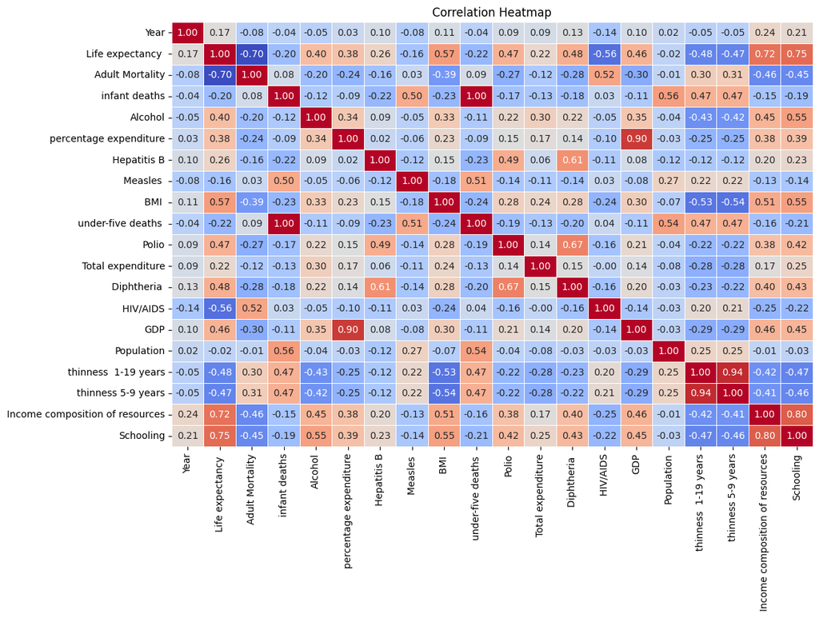

```python
# Correlation heatmap
numeric_cols = df.select_dtypes(include=['int64', 'float64']) #corr() won't work for object dtype so taking separate columns of numerics
plt.figure(figsize=(12, 8))
sns.heatmap(numeric_cols.corr(), annot=True, cmap='coolwarm', fmt='.2f', cbar = False, linewidths=0.5)
plt.title('Correlation Heatmap')
plt.show()
```

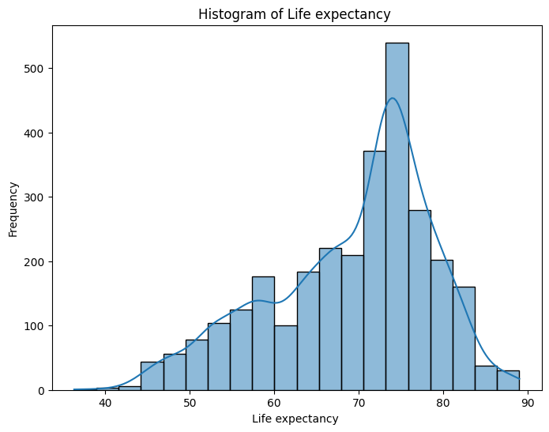

```
Skewness of Life expectancy : -0.638
```

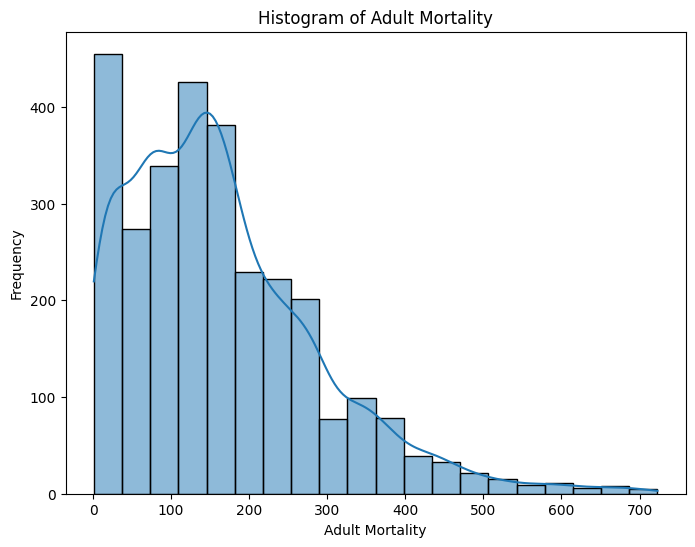

```
Skewness of Adult Mortality: 1.174
```

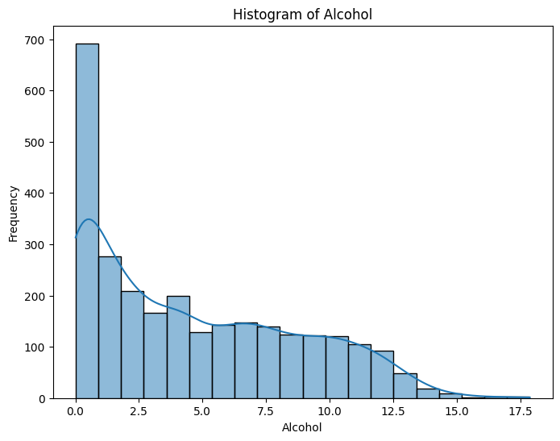

```
Skewness of Alcohol: 0.589
```

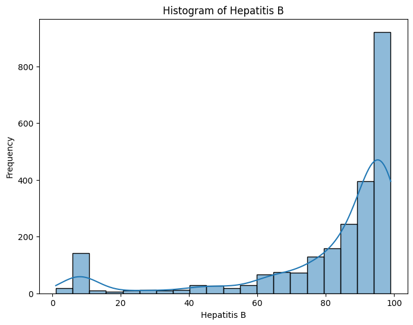

```
Skewness of Hepatitis B: -1.930
```

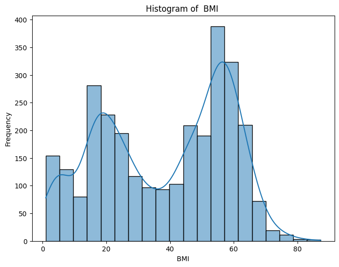

```
Skewness of  BMI : -0.219
```

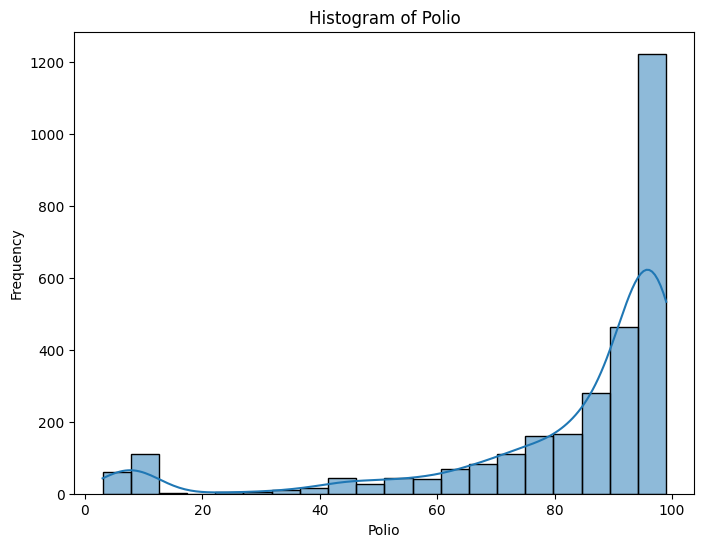

```
Skewness of Polio: -2.097
```

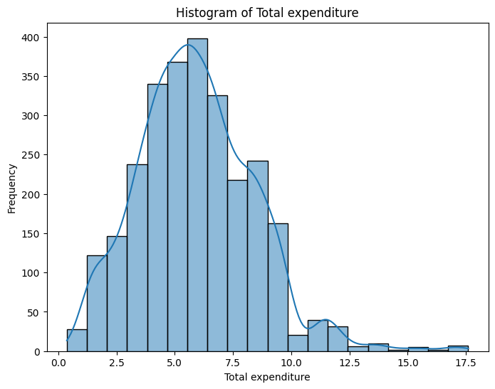

```
Skewness of Total expenditure: 0.618
```

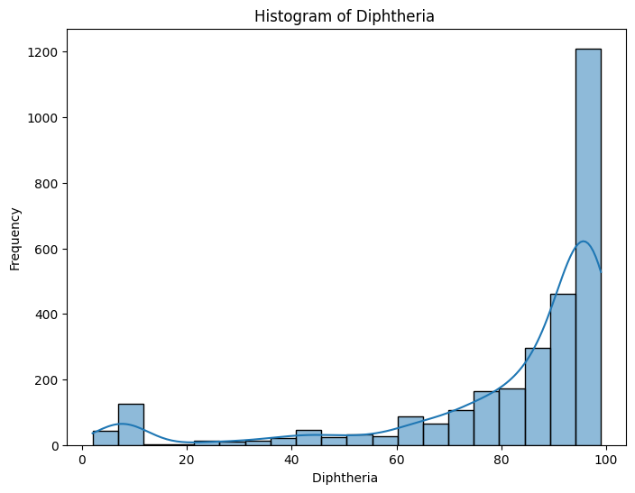

```
Skewness of Diphtheria : -2.072
```

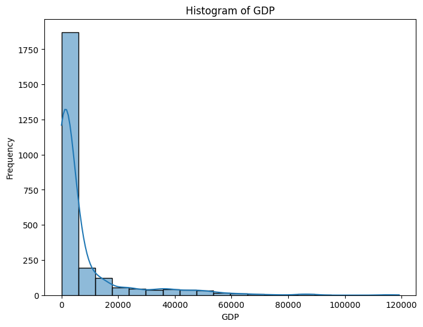

```
Skewness of GDP: 3.205
```

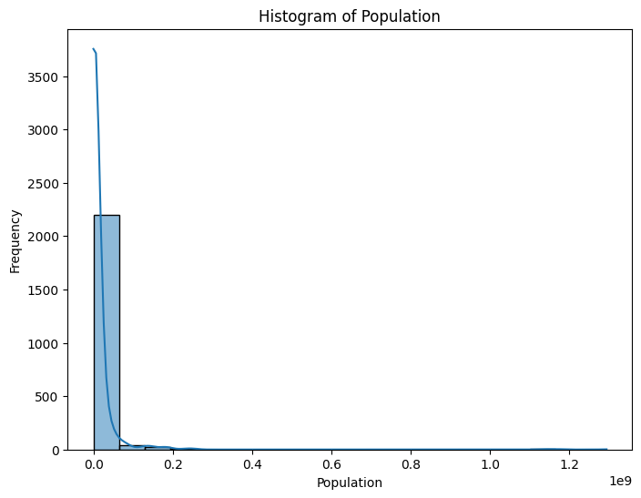

```
Skewness of Population: 15.906
```

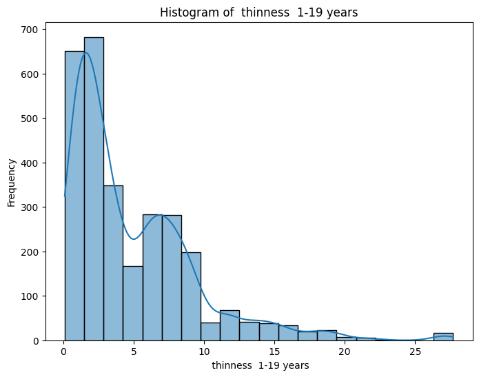

```
Skewness of  thinness  1-19 years: 1.711
```

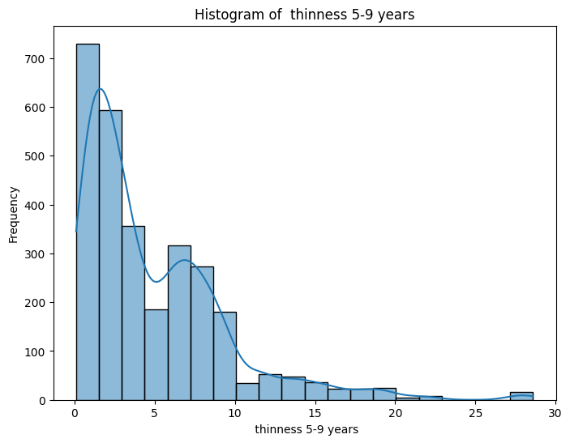

```
Skewness of  thinness 5-9 years: 1.777
```

[2 more figures not shown]

```
Skewness of Schooling: -0.602
```

```python
from scipy.stats import skew

# Loop through each column
for column in df_null.columns:
    # Plot histogram for each column
    plt.figure(figsize=(8, 6))
    sns.histplot(df_null[column], kde=True, bins=20)  # kde=True adds a density plot
    plt.title(f"Histogram of {column}")
    plt.xlabel(column)
    plt.ylabel('Frequency')
    plt.show()

    # Calculate skewness for each column
    if df_null[column].dtype in ['float64', 'int64']:  # Calculate skewness for numeric columns
        column_skew = skew(df_null[column].dropna())  # Drop NaN values before calculating skew
        print(f"Skewness of {column}: {column_skew:.3f}")
```

```python
df.dtypes
```

|  | 0 |
| --- | --- |
| Year | int64 |
| Status | object |
| Life expectancy | float64 |
| Adult Mortality | float64 |
| infant deaths | int64 |
| Alcohol | float64 |
| percentage expenditure | float64 |
| Hepatitis B | float64 |
| Measles | int64 |
| BMI | float64 |
| under-five deaths | int64 |
| Polio | float64 |
| Total expenditure | float64 |
| Diphtheria | float64 |
| HIV/AIDS | float64 |
| GDP | float64 |
| Population | float64 |
| thinness 1-19 years | float64 |
| thinness 5-9 years | float64 |
| Income composition of resources | float64 |
| Schooling | float64 |
| Life_expectancy_category | object |

**dtype:** object

Exploratory Factor Analysis

```python
df.describe().round(2)
```

|  | Year | Life expectancy | Adult Mortality | infant deaths | Alcohol | percentage expenditure | Hepatitis B | Measles | BMI | under-five deaths | Polio | Total expenditure | Diphtheria | HIV/AIDS | GDP | Population | thinness 1-19 years | thinness 5-9 years | Income composition of resources | Schooling |
| --- | --- | --- | --- | --- | --- | --- | --- | --- | --- | --- | --- | --- | --- | --- | --- | --- | --- | --- | --- | --- |
| count | 2938.00 | 2928.00 | 2928.00 | 2938.00 | 2744.00 | 2938.00 | 2385.00 | 2938.00 | 2904.00 | 2938.00 | 2919.00 | 2712.00 | 2919.00 | 2938.00 | 2490.00 | 2.286000e+03 | 2904.00 | 2904.00 | 2771.00 | 2775.00 |
| mean | 2007.52 | 69.22 | 164.80 | 30.30 | 4.60 | 738.25 | 80.94 | 2419.59 | 38.32 | 42.04 | 82.55 | 5.94 | 82.32 | 1.74 | 7483.16 | 1.275338e+07 | 4.84 | 4.87 | 0.63 | 11.99 |
| std | 4.61 | 9.52 | 124.29 | 117.93 | 4.05 | 1987.91 | 25.07 | 11467.27 | 20.04 | 160.45 | 23.43 | 2.50 | 23.72 | 5.08 | 14270.17 | 6.101210e+07 | 4.42 | 4.51 | 0.21 | 3.36 |
| min | 2000.00 | 36.30 | 1.00 | 0.00 | 0.01 | 0.00 | 1.00 | 0.00 | 1.00 | 0.00 | 3.00 | 0.37 | 2.00 | 0.10 | 1.68 | 3.400000e+01 | 0.10 | 0.10 | 0.00 | 0.00 |
| 25% | 2004.00 | 63.10 | 74.00 | 0.00 | 0.88 | 4.69 | 77.00 | 0.00 | 19.30 | 0.00 | 78.00 | 4.26 | 78.00 | 0.10 | 463.94 | 1.957932e+05 | 1.60 | 1.50 | 0.49 | 10.10 |
| 50% | 2008.00 | 72.10 | 144.00 | 3.00 | 3.76 | 64.91 | 92.00 | 17.00 | 43.50 | 4.00 | 93.00 | 5.76 | 93.00 | 0.10 | 1766.95 | 1.386542e+06 | 3.30 | 3.30 | 0.68 | 12.30 |
| 75% | 2012.00 | 75.70 | 228.00 | 22.00 | 7.70 | 441.53 | 97.00 | 360.25 | 56.20 | 28.00 | 97.00 | 7.49 | 97.00 | 0.80 | 5910.81 | 7.420359e+06 | 7.20 | 7.20 | 0.78 | 14.30 |
| max | 2015.00 | 89.00 | 723.00 | 1800.00 | 17.87 | 19479.91 | 99.00 | 212183.00 | 87.30 | 2500.00 | 99.00 | 17.60 | 99.00 | 50.60 | 119172.74 | 1.293859e+09 | 27.70 | 28.60 | 0.95 | 20.70 |

Since *Life Expectancy* is negatively skewed, I will calculate the **median** and **mode** for the target variable to decide the most appropriate value for filling the missing data.

```python
# Calculate the median for Life expectancy
median_life_expectancy = df['Life expectancy '].median()

# Calculate the mode for Life expectancy
mode_life_expectancy = df['Life expectancy '].mode()[0]  # mode() returns a series, take the first mode value

print(f"Median Life expectancy: {median_life_expectancy}")
print(f"Mode Life expectancy: {mode_life_expectancy}")
```

```
Median Life expectancy: 72.1
Mode Life expectancy: 73.0
```

The median and mode values for Life Expectancy are almost identical. After analyzing the heatmap and histogram with skewness, filling the missing values for Life Expectancy with the median is the better choice.

For the other columns, the approach is as follows:

> If the skewness value is between -0.5 and 0.5, fill missing values with the mean. Otherwise, fill missing values with the median

```python
# prompt: Hide warnings

import warnings
warnings.filterwarnings('ignore')
```

```python
# Iterate over all columns to check skewness and fill missing values
for column in df.columns:
    # Check if the column has missing values
    if df[column].isnull().sum() > 0:
        # Check skewness of the column
        skewness = df[column].skew()

        # If the skewness is negative (Left-skewed) or positive (Right-skewed), fill with median
        if skewness < -0.5 or skewness > 0.5:
            df[column].fillna(df[column].median(), inplace=True)
        # If the skewness is near zero (Normal), fill with mean
        else:
            df[column].fillna(df[column].mean(), inplace=True)

# Check if any missing values remain
df.isnull().sum()
```

|  | 0 |
| --- | --- |
| Year | 0 |
| Status | 0 |
| Life expectancy | 0 |
| Adult Mortality | 0 |
| infant deaths | 0 |
| Alcohol | 0 |
| percentage expenditure | 0 |
| Hepatitis B | 0 |
| Measles | 0 |
| BMI | 0 |
| under-five deaths | 0 |
| Polio | 0 |
| Total expenditure | 0 |
| Diphtheria | 0 |
| HIV/AIDS | 0 |
| GDP | 0 |
| Population | 0 |
| thinness 1-19 years | 0 |
| thinness 5-9 years | 0 |
| Income composition of resources | 0 |
| Schooling | 0 |
| Life_expectancy_category | 0 |

**dtype:** int64

Checking duplicate columns

```python
# prompt: check duplicates

# Check for duplicates
duplicates = df[df.duplicated()]
print("Number of duplicate rows:", len(duplicates))
if len(duplicates) > 0:
    print("Duplicate rows:")
duplicates
    # Optionally remove duplicates
    # df.drop_duplicates(inplace=True)
```

```
Number of duplicate rows: 0
```

|  | Year | Status | Life expectancy | Adult Mortality | infant deaths | Alcohol | percentage expenditure | Hepatitis B | Measles | BMI | ... | Total expenditure | Diphtheria | HIV/AIDS | GDP | Population | thinness 1-19 years | thinness 5-9 years | Income composition of resources | Schooling | Life_expectancy_category |
| --- | --- | --- | --- | --- | --- | --- | --- | --- | --- | --- | --- | --- | --- | --- | --- | --- | --- | --- | --- | --- | --- |

0 rows × 22 columns

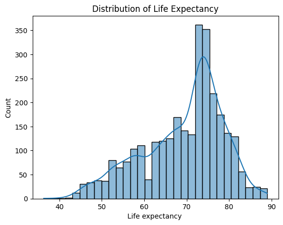

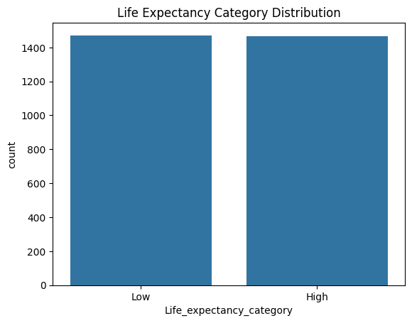

```python
sns.histplot(df['Life expectancy '], kde=True)
plt.title('Distribution of Life Expectancy')
plt.show()

# Plot distribution of Life_expectancy_category (High/Low)
sns.countplot(x='Life_expectancy_category', data=df)
plt.title('Life Expectancy Category Distribution')
plt.show()
```

To handle Status, I will create dummy variables to represent its categories numerically. This process will involve:

1. Generating binary columns for each category in Status.
2. Dropping one dummy variable (if needed) to avoid multicollinearity during modeling.

```python
df['Life_expectancy_category'].value_counts()
```

| Life_expectancy_category | count |
| --- | --- |
| Low | 1472 |
| High | 1466 |

**dtype:** int64

```python
df['Status_Developed'] = df['Status'].apply(lambda x: 1 if x == 'Developed' else 0)
df['Status_Developed'].value_counts()
```

| Status_Developed | count |
| --- | --- |
| 0 | 2426 |
| 1 | 512 |

**dtype:** int64

```python
df['Status_Developing'] = df['Status'].apply(lambda x: 1 if x == 'Developing' else 0)
df['Status_Developing'].value_counts()
```

| Status_Developing | count |
| --- | --- |
| 1 | 2426 |
| 0 | 512 |

**dtype:** int64

```python
# prompt: drop column Status

# Drop the 'Status' column
df = df.drop('Status', axis=1)
```

```python
#df['Life_expectancy_category'] = df['Life_expectancy_category'].map({'High': 1, 'Low': 0})
```

```python
df.shape
```

```
(2938, 23)
```

```python
df.head()
```

|  | Year | Life expectancy | Adult Mortality | infant deaths | Alcohol | percentage expenditure | Hepatitis B | Measles | BMI | under-five deaths | ... | HIV/AIDS | GDP | Population | thinness 1-19 years | thinness 5-9 years | Income composition of resources | Schooling | Life_expectancy_category | Status_Developed | Status_Developing |
| --- | --- | --- | --- | --- | --- | --- | --- | --- | --- | --- | --- | --- | --- | --- | --- | --- | --- | --- | --- | --- | --- |
| 0 | 2015 | 65.0 | 263.0 | 62 | 0.01 | 71.279624 | 65.0 | 1154 | 19.1 | 83 | ... | 0.1 | 584.259210 | 33736494.0 | 17.2 | 17.3 | 0.479 | 10.1 | Low | 0 | 1 |
| 1 | 2014 | 59.9 | 271.0 | 64 | 0.01 | 73.523582 | 62.0 | 492 | 18.6 | 86 | ... | 0.1 | 612.696514 | 327582.0 | 17.5 | 17.5 | 0.476 | 10.0 | Low | 0 | 1 |
| 2 | 2013 | 59.9 | 268.0 | 66 | 0.01 | 73.219243 | 64.0 | 430 | 18.1 | 89 | ... | 0.1 | 631.744976 | 31731688.0 | 17.7 | 17.7 | 0.470 | 9.9 | Low | 0 | 1 |
| 3 | 2012 | 59.5 | 272.0 | 69 | 0.01 | 78.184215 | 67.0 | 2787 | 17.6 | 93 | ... | 0.1 | 669.959000 | 3696958.0 | 17.9 | 18.0 | 0.463 | 9.8 | Low | 0 | 1 |
| 4 | 2011 | 59.2 | 275.0 | 71 | 0.01 | 7.097109 | 68.0 | 3013 | 17.2 | 97 | ... | 0.1 | 63.537231 | 2978599.0 | 18.2 | 18.2 | 0.454 | 9.5 | Low | 0 | 1 |

5 rows × 23 columns

The dataset is now clean and requires no further modifications.

Next Steps:

Prepare Data for OLS Regression:

1. Separate the independent variables (X) and the dependent variable (Y).
2. Ensure no multicollinearity exists by checking the Variance Inflation Factor (VIF).
3. Add a constant term to the dataset for the intercept.

Prepare Data for Logistic (Logit) Regression:

```python
from sklearn.preprocessing import StandardScaler

# Scaling numerical features
scaler = StandardScaler()
scaled_columns = ['Adult Mortality', 'infant deaths', 'Alcohol', 'percentage expenditure', 'Hepatitis B',
                  'Measles ', ' BMI ', 'under-five deaths ', 'Polio', 'Total expenditure', 'Diphtheria ',
                  ' HIV/AIDS', 'GDP', 'Population', ' thinness  1-19 years', ' thinness 5-9 years',
                  'Income composition of resources', 'Schooling']

df[scaled_columns] = scaler.fit_transform(df[scaled_columns])
```

```python
# Data Preprocessing
df = df.dropna()  # Dropping rows with missing values

# Define independent variables (X) and dependent variables (Y)
X = df.drop(['Life expectancy ', 'Life_expectancy_category'], axis=1)  # Drop target columns
y_continuous = df['Life expectancy ']  # For OLS
y_binary = df['Life_expectancy_category'].apply(lambda x: 1 if x == 'High' else 0)  # For Logit

# Add a constant to the independent variables (for intercept)
X = sm.add_constant(X)
```

Verifying above variables

```python
X.shape
```

```
(2938, 22)
```

```python
X.isnull().sum()
```

|  | 0 |
| --- | --- |
| const | 0 |
| Year | 0 |
| Adult Mortality | 0 |
| infant deaths | 0 |
| Alcohol | 0 |
| percentage expenditure | 0 |
| Hepatitis B | 0 |
| Measles | 0 |
| BMI | 0 |
| under-five deaths | 0 |
| Polio | 0 |
| Total expenditure | 0 |
| Diphtheria | 0 |
| HIV/AIDS | 0 |
| GDP | 0 |
| Population | 0 |
| thinness 1-19 years | 0 |
| thinness 5-9 years | 0 |
| Income composition of resources | 0 |
| Schooling | 0 |
| Status_Developed | 0 |
| Status_Developing | 0 |

**dtype:** int64

```python
X.dtypes
```

|  | 0 |
| --- | --- |
| const | float64 |
| Year | int64 |
| Adult Mortality | float64 |
| infant deaths | float64 |
| Alcohol | float64 |
| percentage expenditure | float64 |
| Hepatitis B | float64 |
| Measles | float64 |
| BMI | float64 |
| under-five deaths | float64 |
| Polio | float64 |
| Total expenditure | float64 |
| Diphtheria | float64 |
| HIV/AIDS | float64 |
| GDP | float64 |
| Population | float64 |
| thinness 1-19 years | float64 |
| thinness 5-9 years | float64 |
| Income composition of resources | float64 |
| Schooling | float64 |
| Status_Developed | int64 |
| Status_Developing | int64 |

**dtype:** object

```python
y_continuous.shape
```

```
(2938,)
```

```python
y_binary.shape
```

```
(2938,)
```

```python
y_binary.shape
```

```
(2938,)
```

```python
X.head()
```

|  | const | Year | Adult Mortality | infant deaths | Alcohol | percentage expenditure | Hepatitis B | Measles | BMI | under-five deaths | ... | Diphtheria | HIV/AIDS | GDP | Population | thinness 1-19 years | thinness 5-9 years | Income composition of resources | Schooling | Status_Developed | Status_Developing |
| --- | --- | --- | --- | --- | --- | --- | --- | --- | --- | --- | --- | --- | --- | --- | --- | --- | --- | --- | --- | --- | --- |
| 0 | 1.0 | 2015 | 0.792119 | 0.268824 | -1.156989 | -0.335570 | -0.783807 | -0.110384 | -0.964715 | 0.255359 | ... | -0.735391 | -0.323445 | -0.453371 | 0.435183 | 2.815209 | 2.775386 | -0.737973 | -0.585017 | 0 | 1 |
| 1 | 1.0 | 2014 | 0.856601 | 0.285786 | -1.156989 | -0.334441 | -0.914281 | -0.168124 | -0.989810 | 0.274060 | ... | -0.862233 | -0.323445 | -0.451232 | -0.183349 | 2.883439 | 2.819978 | -0.752600 | -0.615649 | 0 | 1 |
| 2 | 1.0 | 2013 | 0.832421 | 0.302749 | -1.156989 | -0.334594 | -0.827298 | -0.173531 | -1.014905 | 0.292761 | ... | -0.777671 | -0.323445 | -0.449799 | 0.398066 | 2.928926 | 2.864570 | -0.781853 | -0.646281 | 0 | 1 |
| 3 | 1.0 | 2012 | 0.864662 | 0.328193 | -1.156989 | -0.332096 | -0.696824 | 0.032045 | -1.040000 | 0.317696 | ... | -0.650830 | -0.323445 | -0.446924 | -0.120968 | 2.974413 | 2.931458 | -0.815982 | -0.676912 | 0 | 1 |
| 4 | 1.0 | 2011 | 0.888843 | 0.345155 | -1.156989 | -0.367862 | -0.653333 | 0.051757 | -1.060076 | 0.342631 | ... | -0.608549 | -0.323445 | -0.492539 | -0.134268 | 3.042643 | 2.976051 | -0.859862 | -0.768808 | 0 | 1 |

5 rows × 22 columns

```python
# prompt: Check Multicollinearity in X

from statsmodels.stats.outliers_influence import variance_inflation_factor

# Select only numerical features for VIF calculation
numerical_X = X.select_dtypes(include=[np.number])

# Calculate VIF for each independent variable
vif = pd.DataFrame()
vif["VIF Factor"] = [variance_inflation_factor(numerical_X.values, i) for i in range(numerical_X.shape[1])]
vif["features"] = numerical_X.columns

# Display the VIF values
print(vif)

# Identify variables with high VIF (e.g., > 5 or 10)
high_vif_variables = vif[vif["VIF Factor"] > 5]["features"].tolist()
print("\nVariables with high VIF:", high_vif_variables)
```

```
    VIF Factor                         features
0     0.000000                            const
1     1.156983                             Year
2     1.745735                  Adult Mortality
3   177.439050                    infant deaths
4     1.893630                          Alcohol
5     5.817703           percentage expenditure
6     1.312692                      Hepatitis B
7     1.382357                         Measles
8     1.732054                             BMI
9   176.391965               under-five deaths
10    1.938993                            Polio
11    1.220333                Total expenditure
12    2.165191                      Diphtheria
13    1.440993                         HIV/AIDS
14    6.034854                              GDP
15    1.491026                       Population
16    8.774637             thinness  1-19 years
17    8.873672               thinness 5-9 years
18    3.060579  Income composition of resources
19    3.339817                        Schooling
20         inf                 Status_Developed
21         inf                Status_Developing

Variables with high VIF: ['infant deaths', 'percentage expenditure', 'under-five deaths ', 'GDP', ' thinness  1-19 years', ' thinness 5-9 years', 'Status_Developed', 'Status_Developing']
```

**VIF Analysis:** Taking all the required actions to handle multicollinearity because it directly impacts the model's performance and interpretability. Since the target variable is Life Expectancy, ensuring that the independent variables are not highly correlated is crucial for obtaining meaningful results.

To this end:

Removing redundant variables, such as one of the dummy variables

```python
X = X.drop(columns=['Status_Developed'])  # Drop one dummy variable
```

```python
X = X.drop(columns=['infant deaths'])  # Drop 'infant deaths'
```

```python
X = X.drop(columns=[' thinness 5-9 years'])  # Drop one thinness variable
```

```python
# prompt: Check Multicollinearity in X

from statsmodels.stats.outliers_influence import variance_inflation_factor

# Select only numerical features for VIF calculation
numerical_X = X.select_dtypes(include=[np.number])

# Calculate VIF for each independent variable
vif = pd.DataFrame()
vif["VIF Factor"] = [variance_inflation_factor(numerical_X.values, i) for i in range(numerical_X.shape[1])]
vif["features"] = numerical_X.columns

# Display the VIF values
print(vif)

# Identify variables with high VIF (e.g., > 5 or 10)
high_vif_variables = vif[vif["VIF Factor"] > 5]["features"].tolist()
print("\nVariables with high VIF:", high_vif_variables)
```

```
       VIF Factor                         features
0   218628.322844                            const
1        1.155253                             Year
2        1.740310                  Adult Mortality
3        1.863279                          Alcohol
4        5.815092           percentage expenditure
5        1.306227                      Hepatitis B
6        1.377875                         Measles
7        1.707914                             BMI
8        2.169090               under-five deaths
9        1.932031                            Polio
10       1.217091                Total expenditure
11       2.129665                      Diphtheria
12       1.434793                         HIV/AIDS
13       6.022315                              GDP
14       1.443917                       Population
15       1.959429             thinness  1-19 years
16       3.030859  Income composition of resources
17       3.334464                        Schooling
18       1.884117                Status_Developing

Variables with high VIF: ['const', 'percentage expenditure', 'GDP']
```

## OLS Regression

```python
# OLS Regression
ols_model = sm.OLS(y_continuous, X).fit()

# Print OLS summary
print(ols_model.summary())

# Predict with OLS model
y_pred_ols = ols_model.predict(X)

# Calculate RMSE and R-squared
rmse_ols = np.sqrt(mean_squared_error(y_continuous, y_pred_ols))
r2_ols = r2_score(y_continuous, y_pred_ols)

print(f"OLS RMSE: {rmse_ols}")
print(f"OLS R-squared: {r2_ols}")
```

```
                            OLS Regression Results
==============================================================================
Dep. Variable:       Life expectancy    R-squared:                       0.811
Model:                            OLS   Adj. R-squared:                  0.810
Method:                 Least Squares   F-statistic:                     696.8
Date:                Tue, 17 Dec 2024   Prob (F-statistic):               0.00
Time:                        03:39:30   Log-Likelihood:                -8336.5
No. Observations:                2938   AIC:                         1.671e+04
Df Residuals:                    2919   BIC:                         1.682e+04
Df Model:                          18
Covariance Type:            nonrobust
===================================================================================================
                                      coef    std err          t      P>|t|      [0.025      0.975]
---------------------------------------------------------------------------------------------------
const                             108.1745     35.752      3.026      0.003      38.073     178.276
Year                               -0.0187      0.018     -1.052      0.293      -0.054       0.016
Adult Mortality                    -2.5224      0.101    -25.006      0.000      -2.720      -2.325
Alcohol                             0.0784      0.104      0.751      0.453      -0.126       0.283
percentage expenditure              0.1101      0.184      0.597      0.550      -0.251       0.472
Hepatitis B                        -0.4567      0.087     -5.227      0.000      -0.628      -0.285
Measles                            -0.2727      0.090     -3.039      0.002      -0.449      -0.097
 BMI                                0.9120      0.100      9.127      0.000       0.716       1.108
under-five deaths                  -0.3184      0.113     -2.827      0.005      -0.539      -0.098
Polio                               0.7389      0.106      6.952      0.000       0.531       0.947
Total expenditure                   0.1818      0.084      2.155      0.031       0.016       0.347
Diphtheria                          1.1389      0.112     10.207      0.000       0.920       1.358
 HIV/AIDS                          -2.4558      0.092    -26.814      0.000      -2.635      -2.276
GDP                                 0.4858      0.188      2.589      0.010       0.118       0.854
Population                          0.1950      0.092      2.122      0.034       0.015       0.375
 thinness  1-19 years              -0.2446      0.107     -2.286      0.022      -0.455      -0.035
Income composition of resources     1.2943      0.133      9.723      0.000       1.033       1.555
Schooling                           2.2052      0.140     15.794      0.000       1.931       2.479
Status_Developing                  -1.5746      0.277     -5.691      0.000      -2.117      -1.032
==============================================================================
Omnibus:                      135.959   Durbin-Watson:                   0.708
Prob(Omnibus):                  0.000   Jarque-Bera (JB):              388.793
Skew:                          -0.188   Prob(JB):                     3.76e-85
Kurtosis:                       4.742   Cond. No.                     9.39e+05
==============================================================================

Notes:
[1] Standard Errors assume that the covariance matrix of the errors is correctly specified.
[2] The condition number is large, 9.39e+05. This might indicate that there are
strong multicollinearity or other numerical problems.
OLS RMSE: 4.13104951465965
OLS R-squared: 0.811205887931315
```

Updated OLS Regression Results Interpretation

#### Dependent Variable: **Life Expectancy**

### **Evaluation Metrics:**

- **R-squared (R²)**: 0.811
  - **Interpretation**: 81.1% of the variation in life expectancy is explained by the model's predictors. This indicates a good fit for the data.
- **Root Mean Squared Error (RMSE)**: 4.13
- **Interpretation**: The average prediction error is 4.13 years of life expectancy, which is reasonable given real-world variability in life expectancy.

### **Justification of OLS Assumptions:**

1. **Linearity**:
   - Assumes that there is a linear relationship between independent variables and the dependent variable (Life Expectancy). The model seems appropriately specified for this assumption.
2. **Normality of Residuals**:
- **Omnibus test** and **Jarque-Bera (JB) test** indicate that residuals slightly deviate from normality (p < 0.05). However, the model is still effective, and these deviations are not severe enough to question model validity.
3. **Homoscedasticity**:
   - **Durbin-Watson statistic**: 0.708 (ideal value close to 2). This suggests potential autocorrelation in the residuals, which may require further investigation or adjustment.
4. **Multicollinearity**:
- **Condition Number**: 9.39e+05. That is very high, so there might be some multicollinearity between the predictors, affecting stability and interpretability of the coefficients.

### **Model Interpretation:**

#### **Intercept (constant)**: 108.17

- **Interpretation:** This represents the life expectancy when all predictors take value zero, though that value may be practically infeasible.

### **Non-Significant Predictors (p > 0.05)**:

1. **Year**: coef = -0.0187 (p = 0.293)
   - **Interpretation**: In this model, the year variable does not have any significant effect on life expectancy.
2. **Alcohol**: coef = 0.0784 (p = 0.453)
   - **Interpretation**: Alcohol consumption does not significantly affect life expectancy in this dataset.
3. **Percentage Expenditure**: coef = 0.1101 (p = 0.550)
- **Interpretation**: Percentage expenditure does not significantly affect life expectancy.

### **Model Performance**:

1. **R-squared (R²)**: 0.811
   - **Interpretation**: The model explains 81.1% of the variance in life expectancy, meaning a very good fit.
2. **RMSE**: 4.13
   - **Interpretation**: The average prediction error is 4.13 years, which is justifiable for life expectancy data.

### **Key Insights**:

- Health Factors: Adult mortality, under-five deaths, and HIV/AIDS are strongly negatively related to life expectancy. Economic Factors: Higher GDP and income composition are positively related to life expectancy, indicating the role of wealth and resources in improving health outcomes. Educational Impact: Schooling is strongly influential in life expectancy, showing the importance of education in improving health.
- **Healthcare and Immunization**: Investment in healthcare through immunization, such as diphtheria vaccination, and combating diseases such as Hepatitis B and HIV/AIDS, is core to increasing life expectancy.

### **Conclusion**:

The OLS regression model provides a useful perspective on the factors affecting life expectancy. The model is strong, with over 81% of the variance in life expectancy explained. The significant predictors are adult mortality, under-five deaths, HIV/AIDS, schooling, and income composition. However, there is a problem with multicollinearity-as the high condition number shows-maybe affecting the reliability of some coefficients. It therefore needs further refinement, and highly correlated predictors may be removed for even more accurate results.

**Referance:** ChatGPT AI

## Logit Regression

```python
# Logit Regression
logit_model = sm.Logit(y_binary, X).fit()

# Print Logit summary
print(logit_model.summary())

# Predict with Logit model
y_pred_logit = logit_model.predict(X)
y_pred_logit_class = (y_pred_logit >= 0.5).astype(int)  # Convert probabilities to binary classification

# Calculate accuracy
accuracy_logit = accuracy_score(y_binary, y_pred_logit_class)
print(f"Logit Accuracy: {accuracy_logit}")

# Confusion matrix
conf_matrix = confusion_matrix(y_binary, y_pred_logit_class)
print(f"Confusion Matrix:\n{conf_matrix}")
```

```
Optimization terminated successfully.
         Current function value: 0.276955
         Iterations 11
                              Logit Regression Results
====================================================================================
Dep. Variable:     Life_expectancy_category   No. Observations:                 2938
Model:                                Logit   Df Residuals:                     2919
Method:                                 MLE   Df Model:                           18
Date:                      Tue, 17 Dec 2024   Pseudo R-squ.:                  0.6004
Time:                              03:39:30   Log-Likelihood:                -813.69
converged:                             True   LL-Null:                       -2036.5
Covariance Type:                  nonrobust   LLR p-value:                     0.000
===================================================================================================
                                      coef    std err          z      P>|z|      [0.025      0.975]
---------------------------------------------------------------------------------------------------
const                              18.1880     28.759      0.632      0.527     -38.179      74.555
Year                               -0.0098      0.014     -0.684      0.494      -0.038       0.018
Adult Mortality                    -1.8024      0.128    -14.120      0.000      -2.053      -1.552
Alcohol                             0.3151      0.086      3.644      0.000       0.146       0.485
percentage expenditure              1.9372      0.580      3.339      0.001       0.800       3.074
Hepatitis B                         0.0206      0.078      0.263      0.793      -0.133       0.174
Measles                             0.3426      0.124      2.760      0.006       0.099       0.586
 BMI                                0.1037      0.079      1.318      0.188      -0.051       0.258
under-five deaths                  -0.9840      0.330     -2.984      0.003      -1.630      -0.338
Polio                               0.2711      0.090      3.013      0.003       0.095       0.448
Total expenditure                   0.2072      0.077      2.686      0.007       0.056       0.358
Diphtheria                          0.1394      0.096      1.455      0.146      -0.048       0.327
 HIV/AIDS                          -6.9512      1.059     -6.563      0.000      -9.027      -4.875
GDP                                 0.6496      0.361      1.798      0.072      -0.059       1.358
Population                         -0.1965      0.153     -1.286      0.199      -0.496       0.103
 thinness  1-19 years               0.0010      0.088      0.012      0.991      -0.171       0.173
Income composition of resources     0.4193      0.095      4.407      0.000       0.233       0.606
Schooling                           0.5345      0.130      4.110      0.000       0.280       0.789
Status_Developing                  -0.2254      0.289     -0.779      0.436      -0.793       0.342
===================================================================================================

Possibly complete quasi-separation: A fraction 0.17 of observations can be
perfectly predicted. This might indicate that there is complete
quasi-separation. In this case some parameters will not be identified.
Logit Accuracy: 0.882573179033356
Confusion Matrix:
[[1267  205]
 [ 140 1326]]
```

The *Logit Regression Results* depict the relationship of various predictors with the *Life Expectancy Category* based on 2938 observations. The following are the findings:

### Significant Predictors:

1. **Adult Mortality** (*p-value < 0.001*): Strong negative effect on life expectancy.
2. **Alcohol** (*p-value < 0.001*): Positive effect on life expectancy.
3. **Percentage Expenditure** (*p-value = 0.001*): Positive effect on life expectancy.
4. **Measles** (*p-value = 0.006*): Positive effect on life expectancy.
5. **Under-Five Deaths** (*p-value = 0.003*): Negative impact on life expectancy.
6. **Polio** (*p-value = 0.003*): Positive effect on life expectancy.
7. **Total Expenditure** (*p-value = 0.007*): has a positive influence on life expectancy.
8. **HIV/AIDS** (*p-value < 0.001*): has a significant negative impact on life expectancy.
9. **Income Composition of Resources** (*p-value < 0.001*): has a positive impact on life expectancy.
10. **Schooling** (*p-value < 0.001*): also has a positive impact on life expectancy.

### Insignificant Predictors:

- **Year**, **Hepatitis B**, **BMI**, **Diphtheria**, **GDP**, **Population**, **Thinness (1-19 years)**, and **Status_Developing** were not significant in the prediction of life expectancy based on their *p-values* being above 0.05.

### Model Performance:

*Pseudo R-squared*: **0.6004** is indicative that about **60%** of the variance in the outcome is explained by this model. *Log-Likelihood*: **-813.69** is representative that the model converged successfully.

### Issues:

- **Complete quasi-separation detected**, which essentially means a fraction, **17%**, of the observations can be perfectly predicted, possibly leading to non-identification of some parameters due to perfect separation in the data.

```python
from sklearn.metrics import precision_score, recall_score

precision_logit = precision_score(y_binary, y_pred_logit_class)
recall_logit = recall_score(y_binary, y_pred_logit_class)

print(f"Logit Precision: {precision_logit}")
print(f"Logit Recall: {recall_logit}")
```

```
Logit Precision: 0.8661005878510777
Logit Recall: 0.9045020463847203
```

**Precision (0.8661):** This measures the proportion of positive predictions (i.e., the predicted positive class) that were actually correct. In this case, 86.61% of the instances predicted as positive are truly positive. Precision is important when the cost of false positives is high (e.g., when predicting diseases or fraud).

**Recall (0.9045):** This measures the proportion of actual positive instances that were correctly identified by the model. In this case, 90.45% of the true positive instances were correctly classified as positive. Recall is important when the cost of false negatives is high (e.g., missing a disease diagnosis).

## Visualizations

### OLS Graphs

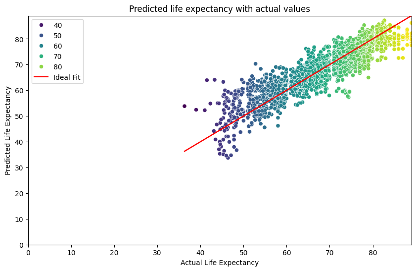

```python
# OLS
plt.figure(figsize=(10, 6))
sns.scatterplot(x=y_continuous, y=y_pred_ols, hue=y_continuous, palette='viridis')
plt.plot([min(y_continuous), max(y_continuous)], [min(y_continuous), max(y_continuous)], color='red')
sns.lineplot(x=y_continuous, y=y_continuous, color="red", label="Ideal Fit")
plt.title("Predicted life expectancy with actual values")
plt.xlabel("Actual Life Expectancy")
plt.ylabel("Predicted Life Expectancy")
plt.legend()

# Set the graph to start from 0
plt.xlim(0, max(max(y_continuous), max(y_pred_ols)))
plt.ylim(0, max(max(y_continuous), max(y_pred_ols)))

plt.show()
```

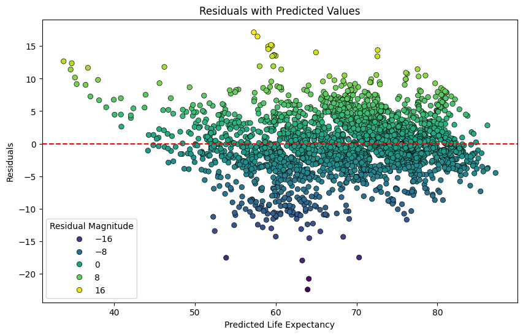

```python
residuals = y_continuous - y_pred_ols

plt.figure(figsize=(10, 6))

# Use hue for the residual values
sns.scatterplot(
    x=y_pred_ols,
    y=residuals,
    hue=residuals,
    palette="viridis",
    edgecolor="black"
)

plt.axhline(0, color='red', linestyle='--')  # Reference line for zero residuals
plt.title("Residuals with Predicted Values")
plt.xlabel("Predicted Life Expectancy")
plt.ylabel("Residuals")
plt.legend(title="Residual Magnitude")
plt.show()
```

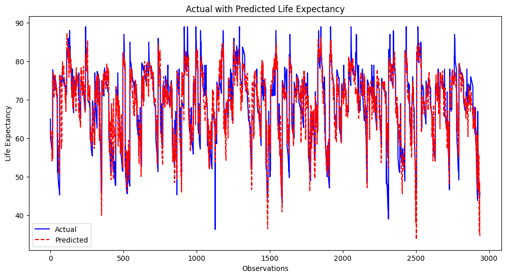

```python
plt.figure(figsize=(12, 6))
plt.plot(y_continuous.values, label="Actual", color="blue")
plt.plot(y_pred_ols, label="Predicted", color="red", linestyle="--")
plt.title("Actual with Predicted Life Expectancy")
plt.xlabel("Observations")
plt.ylabel("Life Expectancy")
plt.legend()
plt.show()
```

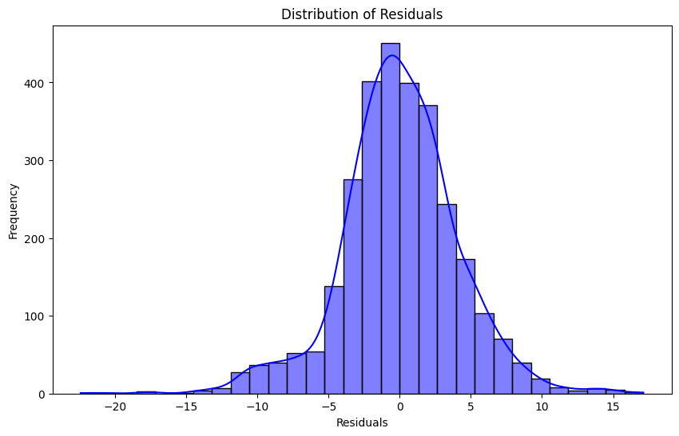

```python
# Histogram of Residuals
plt.figure(figsize=(10, 6))
sns.histplot(residuals, bins=30, kde=True, color="blue")
plt.title("Distribution of Residuals")
plt.xlabel("Residuals")
plt.ylabel("Frequency")
plt.show()
```

### Logit Regression Graphs

#### ROC Curve

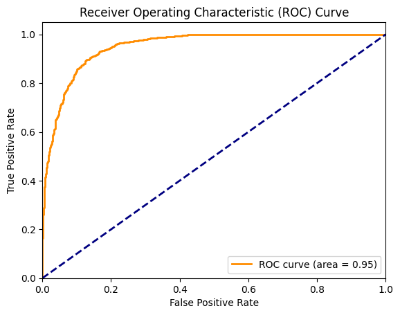

```python
# ROC Curve for Logit Regression
fpr, tpr, _ = roc_curve(y_binary, y_pred_logit)
roc_auc = auc(fpr, tpr)

# Plotting ROC Curve
plt.figure()
plt.plot(fpr, tpr, color='darkorange', lw=2, label=f'ROC curve (area = {roc_auc:.2f})')
plt.plot([0, 1], [0, 1], color='navy', lw=2, linestyle='--')
plt.xlim([0.0, 1.0])
plt.ylim([0.0, 1.05])
plt.xlabel('False Positive Rate')
plt.ylabel('True Positive Rate')
plt.title('Receiver Operating Characteristic (ROC) Curve')
plt.legend(loc="lower right")
plt.show()
```

#### Confusion Matrix

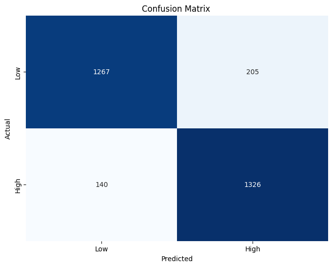

```python
plt.figure(figsize=(8, 6))
sns.heatmap(conf_matrix, annot=True, fmt='d', cmap='Blues', xticklabels=['Low', 'High'], yticklabels=['Low', 'High'], cbar=False)
plt.title("Confusion Matrix ")
plt.xlabel("Predicted")
plt.ylabel("Actual")
plt.show()
```

#### Probability Distribution

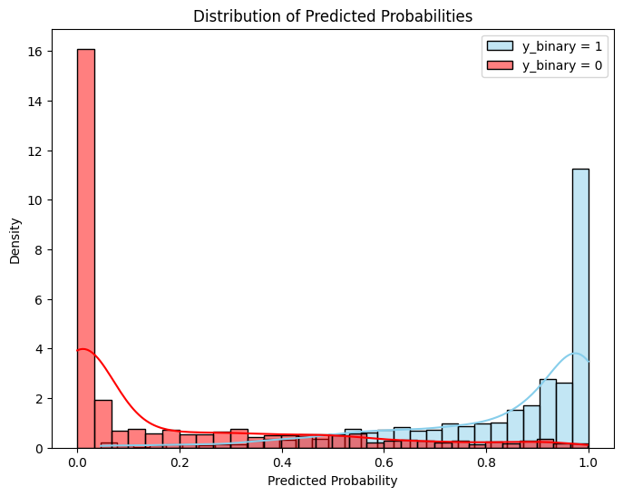

```python
# Separate the predicted probabilities based on the binary classification
y_pred_logit_1 = y_pred_logit[y_binary == 1]
y_pred_logit_0 = y_pred_logit[y_binary == 0]

# Create the histogram with different colors for each class
plt.figure(figsize=(8, 6))

# Plot for y_binary = 1
sns.histplot(y_pred_logit_1, kde=True, color='skyblue', bins=30, label='y_binary = 1', stat='density')

# Plot for y_binary = 0
sns.histplot(y_pred_logit_0, kde=True, color='red', bins=30, label='y_binary = 0', stat='density')

# Add labels and title
plt.title("Distribution of Predicted Probabilities")
plt.xlabel("Predicted Probability")
plt.ylabel("Density")
plt.legend()
plt.show()
```

#### Analysis

The provided visualizations show the performance of the model from different perspectives. From the confusion matrix, the overall good accuracy of the model, with a very high number of correct predictions in both classes, is evident. The ROC-AUC further cements this very good performance and presents very good discriminatory power with an AUC of 0.95, hence this model is able to differentiate well between positive and negative instances across a wide range of classification thresholds. The distribution of predicted probabilities indicates that this model is well-calibrated; it assigns higher probabilities to the instances which actually belong to the positive class and lower probabilities to those belonging to the negative class. That would mean the model is pretty aware of the underlying patterns and is likely to make reliable predictions. Overall, the model presents robust performance and can be viewed as a reliable tool in classification tasks.

## Other Information

Here is the link to my [Digital Resume](https://ashokmedasani.github.io), where you can verify my projects for extra credit consideration

```python
from nbconvert import HTMLExporter
import nbformat

# Load the notebook
notebook_path = "/content/drive/MyDrive/FALL2-AA5000/Final Project/life_expectancy_assignment.ipynb"
output_html_path = "/content/drive/MyDrive/FALL2-AA5000/Final Project/life_expectancy_assignment.html"

with open(notebook_path) as f:
  notebook_content = nbformat.read(f, as_version=4)

# Convert to HTMl
html_exporter = HTMLExporter()
(body, resources) = html_exporter.from_notebook_node(notebook_content)

# save to HTML file
with open(output_html_path, 'w') as f:
  f.write(body)
```